# Problem Set 4

### 5.2 - Estimating the Factors

#### 5.2a - Principal Component Analysis

```r
Z <- fm |>
  select(-date) |>
  as.matrix()

pc <- prcomp(scale(Z))

summary(pc)$importance[, 1:5]
```

```
                            PC1      PC2      PC3      PC4      PC5
Standard deviation     4.258002 2.993839 2.923106 2.597224 2.295261
Proportion of Variance 0.149840 0.074070 0.070620 0.055750 0.043540
Cumulative Proportion  0.149840 0.223910 0.294530 0.350280 0.393820
```

```r
sum(summary(pc)$importance[2, 1:3])
```

```
[1] 0.29453
```

The first three principal components explain about 29.45% of the total variation in the 121 economic series. The first component explains about 14.98%, while the second and third explain around 7.41% and 7.06%. This shows that a small number of factors can summarize a substantial amount of information from the dataset.

#### 5.2b - First Principal Component

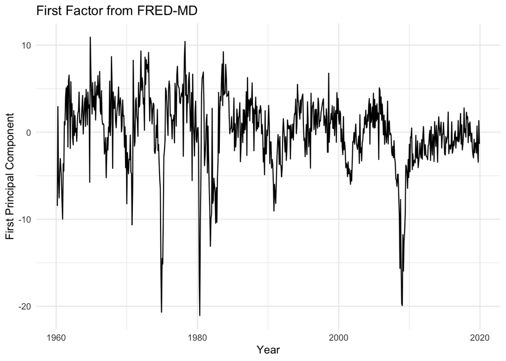

```r
F1 <- pc$x[, 1] * sign(cor(pc$x[, 1], fm$INDPRO))

tibble(date = fm$date, F1 = F1) |>
  ggplot(aes(x = date, y = F1)) +
  geom_line() +
  labs(
    title = "First Factor from FRED-MD",
    x = "Year",
    y = "First Principal Component"
  ) +
  theme_minimal()
```

The first factor moves around zero and has some large negative drops, especially during the mid-1970s, early 1980s, and 2008–2009. These periods line up with major economic slowdowns. Since the factor is positively correlated with industrial production, it seems to capture changes in overall economic activity. Higher values generally suggest stronger activity, while lower values suggest weaker activity.

#### 5.2c - Interpreting the Factors

```r
factor1_corr <- readRDS("results/factor1_corr.rds")
factor2_corr <- readRDS("results/factor2_corr.rds")

factor1_corr
```

```
   PAYEMS IPMANSICS    USGOOD    INDPRO    MANEMP   IPFPNSS    CUMFNS   DMANEMP
0.8415788 0.8404473 0.8390159 0.8219976 0.8028499 0.7903078 0.7778686 0.7768615
```

```r
factor2_corr
```

```
    CUSR0000SAC DNDGRG3M086SBEA   CUSR0000SA0L2        CPIAUCSL   CUSR0000SA0L5
      0.7468587       0.7391330       0.7279202       0.7198020       0.7020307
       CPITRNSL           PCEPI        CPIULFSL
      0.6806883       0.6795890       0.6570361
```

The first factor seems to capture overall economic activity. The variables most correlated with it include employment, industrial production, and manufacturing activity. This also matches the graph from the previous question, where the factor drops sharply during major economic slowdowns.

The second factor appears to capture inflation and price movements. Most of its strongest correlations are with CPI and PCE price indexes, including commodity prices, transportation prices, and overall consumer prices. This suggests that the factor summarizes common changes in prices across the economy.

### 5.3 - Forecasting Industrial Production

```r
ip_results <- readRDS("results/ip_results.rds")

knitr::kable(
  data.frame(
    Model = c("AR(1)", "AR(1) + 3 Factors"),
    RMSE = as.numeric(ip_results)
  ),
  digits = 3
)
```

| Model | RMSE |
| --- | --- |
| AR(1) | 0.617 |
| AR(1) + 3 Factors | 0.589 |

The AR(1) model has an RMSE of 0.617, while the model with three factors has an RMSE of 0.589. These results match the values from class. Adding the factors improves forecasting accuracy by about 4.6%, suggesting that information from other economic variables helps predict industrial production growth.

It would be cheating to estimate the factors using the full dataset because that would include future information in earlier forecasts. By re-estimating the factors at each forecast origin, we only use information that would have been available at that time.

### 5.4 - Forecasting 12-Month CPI Inflation

```r
inflation_results <- readRDS("results/inflation_results.rds")

inflation_results |>
  knitr::kable(digits = 3)
```

| series | forecasts | RMSE_AR | RMSE_FA | MAE_AR | MAE_FA | DM_pvalue |
| --- | --- | --- | --- | --- | --- | --- |
| CPIAUCSL | 349 | 2.108 | 1.894 | 1.578 | 1.349 | 0 |

```r
# Percentage improvement in RMSE
100 * (inflation_results$RMSE_AR -
       inflation_results$RMSE_FA) /
       inflation_results$RMSE_AR
```

```
[1] 10.16198
```

The model with three factors performs better than the model using only past inflation. The RMSE decreases from 2.11 to 1.89, which is an improvement of about 10.16%. The MAE also decreases from 1.58 to 1.35.

The DM test gives a p-value of 0.000443, which is below 0.05. This means the difference in forecasting accuracy is statistically significant. Overall, adding information from the economic factors seems to help predict inflation over the next 12 months.

## Reflection

One thing I noticed throughout this assignment is that more complicated forecasting models don’t always give better results. For example, VAR(1) performed better than VAR(4) for most of the variables, even though VAR(4) uses more information. The forecast combination also didn’t beat ARIMA alone, showing that averaging models is not always helpful. However, adding economic factors improved the forecasts for both industrial production and inflation. This shows that using more information can be useful, but it doesn’t always lead to better forecasts.